# STA 100 R Handout - ANOVA Bonferroni CI, Proportions

Erin K. Melcon

# Calculating the $t_{\alpha/(2k)}$ value

To calculate the value of $t_{\alpha/(2k)}$ using R, you may use the following command: `qt(1-alpha/(2*k), df = n. - I)` Where you have to input the values of `alpha`, `k`, `n.`, and `I`.

For example, say I wanted a family/simultaneous/overall confidence level of 99%, I was making 6 confidence intervals total, n. =100, and I = 4.

The value of $t_{\alpha/(2k)}$ would be:

```r
qt(1-0.01/(2*6),100-4)
```

```
## [1] 3.235452
```

Make sure that you have the parenthesis in the correct place (as they are above).

### 1. The data

For this handout, I will use a built in dataset that is already in R (so you do not have to load a dataset to use this handout). For your homework, you will read in the data as we usually do.

The dataset is called `PlantGrowth`, and you can learn about it by typing `?PlantGrowth` into R. the names of `PlantGrowth` are:

```r
names(PlantGrowth)
```

```
## [1] "weight" "group"
```

The column `weight` is numeric, while the column `group` is a categorical value. `weight` represents the weight in ounces of plants, and `group` has values `ctrl` (control), `trt1` (treatment 1), and `trt2` (treatment 2).

The goal is to use ANOVA to see if the group means are different, and then find which were different using Bonferroni confidence intervals.

### 1. Installing a new package

For Bonferroni confidence intervals, we have to install a new package called `asbio`. There are a number of ways to do this, and especially if you have a MAC, you may have to try one or two.

### 1.1. Giving R the code

If you type in your console (once) the following: `install.packages("asbio")` you should get a prompt that says that R would like to install some things. Press yes. Now it should be installed.

### 1.2. Using the drop down menus

You can also use the menu in Rstudio to install the package, by going

Tools -> Install Packages

and then typing `asbio` into the prompt. Note, for MACs this will be slightly different, but the same idea.

### 1.3. If you have a MAC and are having trouble.

If you are having trouble, specifically with the `tcltk` package, **you may have to install a program called Xquartz**:

https://www.xquartz.org/

Here is a link which describes someones experience with this problem:

http://stackoverflow.com/questions/26511913/installing-using-the-asbio-package-under-os-x

So if you have a MAC and you are having problems, first install Xquartz, then try re-installing the package.

If the above doesn’t help, feel free to email me.

### 2. Load the package

To use all the things in the new package we installed, in our code block we must now put

```r
library(asbio)
```

(Note, you have to install the package first using the above, and then do this step).

Now, we are ready to use a function that will calculate Bonferroni Confidence intervals for us!

### 3. Bonferroni Confidence intervals

There is now a function in r called `bonfCI`. You give it the **columns** of your dataset, not just the name of the columns, and the level of confidence you want. The general form is:

`bonfCI(datasetname$numericcolumnname, datasetname$groupcolumnname,conf.level = 1-alpha)`

So for my data, I would do the following:

```r
library(asbio)
bonfCI(PlantGrowth$weight,PlantGrowth$group,conf.level = 0.95)
```

```
##
## 95% Bonferroni confidence intervals
##
##                 Diff    Lower    Upper  Decision Adj. p-value
## muctrl-mutrt1  0.371 -0.34058  1.08258    FTR H0     0.583164
## muctrl-mutrt2 -0.494 -1.20558  0.21758    FTR H0     0.263045
## mutrt1-mutrt2 -0.865 -1.57658 -0.15342 Reject H0     0.013378
```

And it will display all the confidence intervals we would want. It gives the following, in order, for each row:  
1. The difference it calculated  
2. The value of ($\bar{y}_a - \bar{y}_b$).  
3. The lower bound of the confidence interval.  
4. The upper bound of the confidence interval.  
5. The decision on whether or not to reject H0 or fail to reject (FTR) H0.  
6. The associated p-value for the hypothesis test $\mu_a= \mu_b$

Notice for my data, we only rejected the hypothesis that the two treatment groups had equal means.

### 4.1 Assessing normality of the errors (QQ plot):

To check the normality assumption, first we need to find the vector of residuals or errors (the values of $e_{ij}$). First we save the ANOVA model, and then extract the residuals:

```r
the.model = lm(weight~group, data = PlantGrowth)
eij = the.model$residuals
```

Now, we can check to see with a QQ plot if the errors look approximately normally distributed:

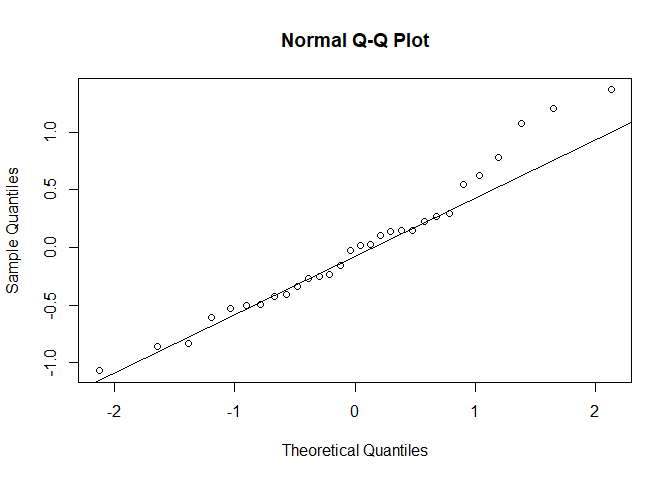

```r
qqnorm(eij)
qqline(eij)
```

Note that “weight” should be the name of your numeric column, “group” should be the name of your grouping column, and “PlantGrowth” should be the name of your dataset.

### 4.2 Testing for normality (Shapiro-Wilks)

In addition to assessing normality, we can test for normality. The null hypothesis is:

$$H_0: \text{The errors are normaly distributed}$$
vs
$$H_A: \text{The errors are not normally distributed}$$

Thus, if we reject the null we conclude that the normality of errors assumption has been violated. The specific test we will use is called the Shaprio-Wilk test for normality.

To find the test-statistic and p-value, we can use the function `shapiro.test`:

```r
shapiro.test(eij)
```

```
##
##  Shapiro-Wilk normality test
##
## data:  eij
## W = 0.96607, p-value = 0.4379
```

In this case, the p-value is much larger than any reasonable alpha, so we fail to reject the null. In other words, we conclude the errors are approximately normally distributed.

## Categorical Data

**Note, the following is adding data to R, you do not need to do this step. You will read in the data from a .csv or .txt as usual**

```r
trees = data.frame(species = rep(c("native","non"),times = c(54,12)))
squash = data.frame(color = rep(c("white","yellow","green"),times = c(155,40,10)))
```

`trees` is a random sample of trees, which were identified as native or non-native. `squash` is a random sample of squash, which were identified by color.

Notice the format of the data `trees` is that it has two categories contained in one column, and `squash` has three categories contained in one column.

### 5. Making a frequency table

For all of the following functions, they expect to be given a **frequency table** (a table with the possible categories, and the associated counts or frequencies for each category). To make a frequency table, we give the function `table` one or more columns of our dataset.

#### 5.1. A one row frequency table

To make a one row (single categorical variable) frequency table, you use `table` on one column of your dataset:

```r
tree.table = table(trees$species)
tree.table
```

```
##
## native    non
##     54     12
```

For the squash data, the table of counts would be:

```r
squash.table = table(squash$color)
squash.table
```

```
##
##  green  white yellow
##     10    155     40
```

To access the $i^{th}$ value in the table, you may use the command

table.name[i]

where you put in a number 1, 2, … , k in for i, and what you called your table for table.name. From this table, we can tell that

```r
tree.table[1]
```

```
## native
##     54
```

trees are a native species. R assigns the catories by column in alphabetical order.

### 6. Confidence interval for a proportion:

To get the total number of subjects with the trait, we use whatever value from our table is appropriate. Lets say I would like a confidence interval for the proportion of native trees. Since the native column is in the first column (due to alphabetical ordering), I would make

```r
y = tree.table[1]
```

For the total sample size, I want to sum up the table, which can be done through the following command:

```r
n = sum(tree.table)
```

```r
prop.test(y+2,n+4,conf.level = 0.95,correct = FALSE)$conf.int
```

```
## [1] 0.6918336 0.8769526
## attr(,"conf.level")
## [1] 0.95
```

This gives the lower and upper bound of my confidence interval, as well as the confidence level. You have to set what y and n are equal to, and then make sure to add the correction to R, and make sure that you set correct=FALSE (or else R will do a different correction). You can change the confidence level by changing 0.95 to something else.